# World Progress and Development Indicators

# Global life expectancy steadily increasing

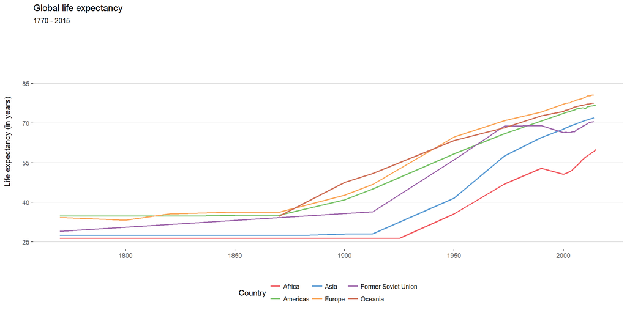

# Life expectancy very high in Europe and Central Asia, inconsistent in East Asia and the Pacific

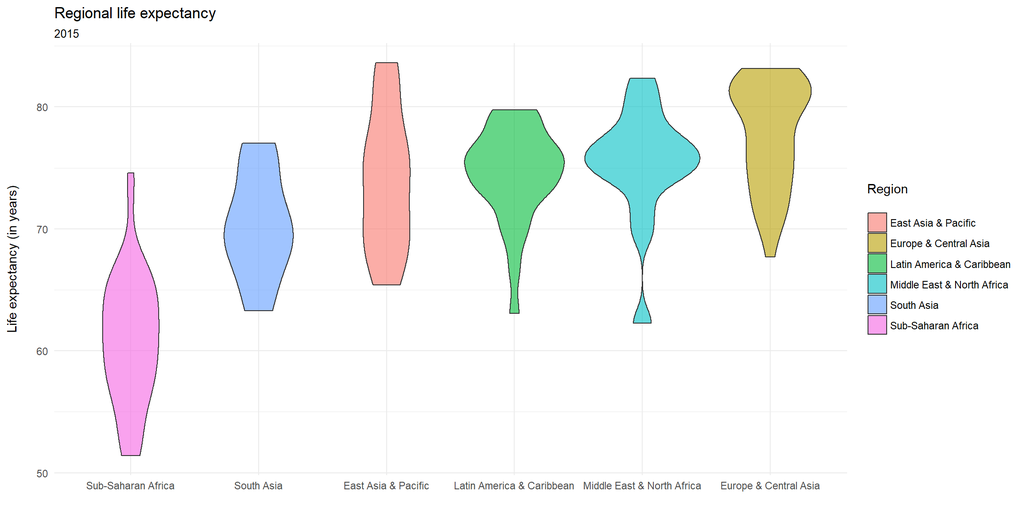

This visualization looks at life expectancy from a different angle, this time as a distribution within a single year (2015). The distributions are also ordered left to right from lowest to highest average life expectancy. Again, Europe had the highest life expectancy in 2015 while Africa had the lowest. The degree to which these regional life expectancies are centered and spread around their mean is also visible. The three regions with the highest average life expectancy, also have the most consistent life expectancies in terms of how centered their distributions are. The regions with lower average life expectancies have more spread distributions. I chose to use a violin plot to see this relationship more clearly.

# Regional Human Development Index scores

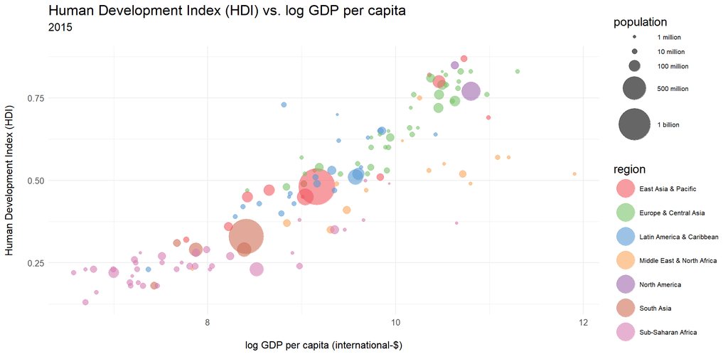

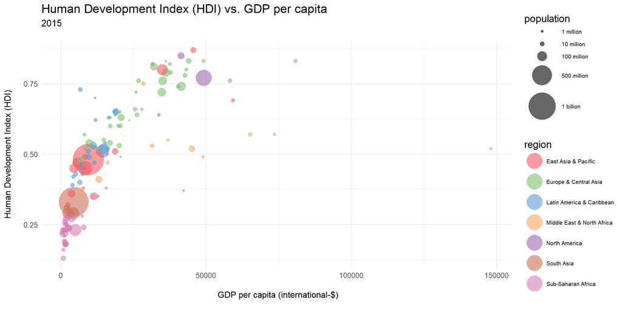

Human development index scores versus Gross Domestic Product per capita of a subset of countries from different regions are plotted above. Not only is region mapped to the colour of the data points, but the size of each data point is also mapped to the population size of the country. Mapping attributes this way across two correlated measures serves the purpose of allowing the viewer to see how regions cluster together, as well as how some countries may be dissimilar to others in their region in terms of HDI and GDP. The lower plot uses a non-transformed GDP scale and it can be seen that a huge outlier is shifting the entire plot to make the actual regional relationship between HDI and GDP look very different. After converting the GDP scale to a log scale, the relationship is easier to see. Most regions are quite similar in terms of HDI vs GDP. This makes sense because they are two significant and related developmental indicators. There are some interesting countries which stand apart from their respective regions. This is one plot where choosing print-friendliness rather than interactivity might take away from the display. It is also interesting that the size of the country doesn’t seem to be related much to HDI nor GDP. There does not appear to be any size clusters in this display.

# A closer look at the Human Development Index

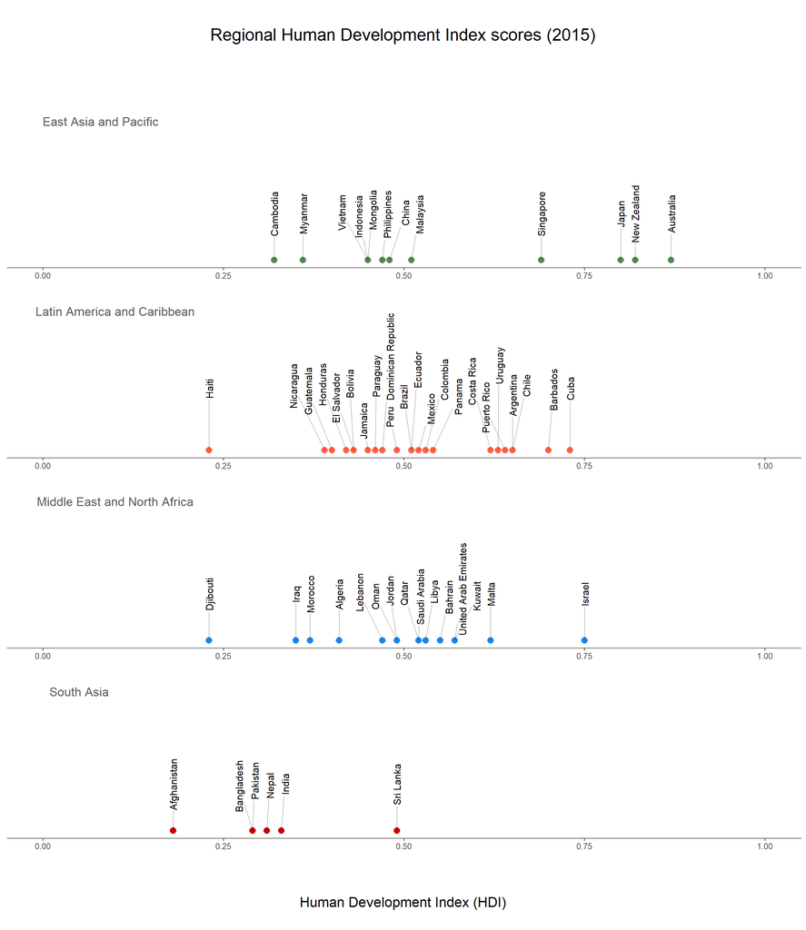

Sticking with the multiple perspectives theme, this plot is a different take on Human Development Index scores. I arrived at this plot through a lot of experimentation with R; it is a plot which I believe is completely unique (but I may be wrong). What makes this plot simple yet unique is that I have grouped each region into its own quarter of the plot (vertically) and visualized each group across a single dimension. Vertical grouping works seamlessly here because there is no y-axis included. When planning this plot, I thought about how I might deconstruct a scatter plot to allow for a single dimension. A dot-plot would be too difficult to interpret with all groups included and encoded with colours. Furthermore, I couldn’t find an existing plot which nailed both colour and 2-D position along the x-axis the way I wanted. This custom plot allows the viewer to see each unique data point with no overlap or jittering required. Because each region shares the same scale, relative comparisons between positions can be made easily both within and between regions. This plot allows viewers to see the top and bottom country in all regions and overall (in terms of HDI) and it also points out around which values each region is spread across in terms of HDI. The only cluttering issue I ran into involved the ability to include labels for each data point (keeping with a print-friendly theme). This was solved by simply repelling the labels away from each data point and jittering the labels rather than the data points themselves (as the labels take up more room on the plot).

# Female school enrollment (% of gross)

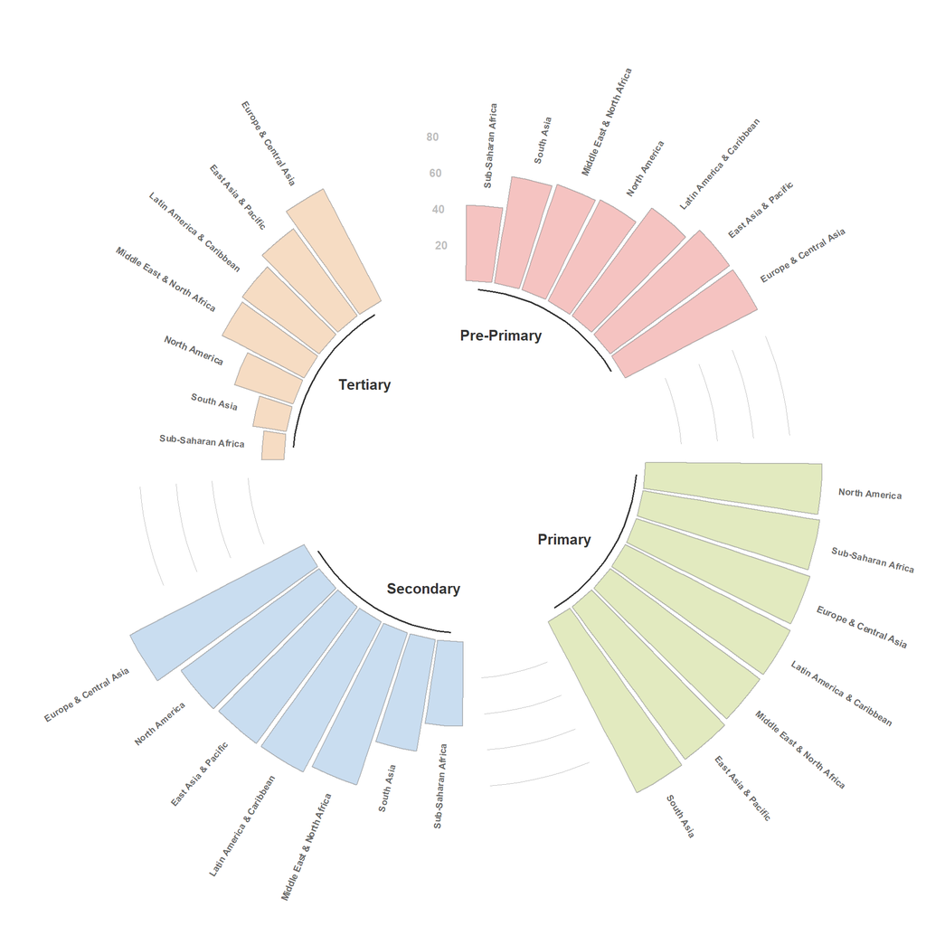

This plot represents an interesting looking, eye-catching, yet ineffective plot. I wanted to include one such plot to highlight why eye-catching plots are often poorly designed and not very valuable in terms of the knowledge they convey. This plot simply visualizes female educational enrollment rates at different levels of education across regions of the world. Because the coordinates of this plot are polar (wrapping around in a circle), comparisons made within education levels are quite difficult and not accurate while comparisons made between education levels are almost impossible. One reason why this is the case is that these sub-plots do not share a common starting point for each bar. Instead, each bar starts at a different place around the inner circle. This makes it hard to gage relative heights of each bar, and thus, their relative values. Another weakness which makes interpreting this plot difficult is that it uses one y-axis scale for each of the four plots. This is made slightly better by the fact that there are horizontal line segments between each plot to denote those y-values. Overall, this plot looks interesting but is not very informative.